# REVIEW R BASICS

### 5.1 The “heights” dataset

The **heights** dataset includes heights and sex reported by students in an in-class survey.

```r
library(dslabs)
data(heights)
options(digits = 3) # report 3 significant digits for all answers.
```

See the structure of this dataset:

```r
str(heights)
```

```
## 'data.frame':    1050 obs. of  2 variables:
##  $ sex   : Factor w/ 2 levels "Female","Male": 2 2 2 2 2 1 1 1 1 2 ...
##  $ height: num  75 70 68 74 61 65 66 62 66 67 ...
```

Determine the average height:

```r
mean(heights$height)
```

```
## [1] 68.3
```

Create a logical index for those individuals who are above average:

```r
ind <- heights$height > mean(heights$height)
```

How many individuals in the dataset are above average height?

```r
sum(ind)
```

```
## [1] 532
```

How many individuals in the dataset are above average height and are female?

```r
sum(ind & heights$sex == "Female")
```

```
## [1] 31
```

What proportion of individuals in the dataset are female?

```r
mean(heights$sex == "Female")
```

```
## [1] 0.227
```

Determine the minimum height in the heights dataset.

```r
min(heights$height)
```

```
## [1] 50
```

Use the `match()` function to determine the index of the first individual with the minimum height.

```r
match(50,heights$height)
```

```
## [1] 1032
```

Subset the `sex` column of the dataset to determine the individual’s sex:

```r
heights$sex[match(50,heights$height)]
```

```
## [1] Male
## Levels: Female Male
```

Determine the maximum height:

```r
max(heights$height)
```

```
## [1] 82.7
```

Which integer values are between the maximum and minimum heights?

```r
x <- 50:82
x
```

```
##  [1] 50 51 52 53 54 55 56 57 58 59 60 61 62 63 64 65 66 67 68 69 70 71 72 73 74
## [26] 75 76 77 78 79 80 81 82
```

How many of the integers in `x` are NOT heights in the dataset?

```r
sum(!(x %in% heights$height))
```

```
## [1] 3
```

Another method for aggregating is using the **dplyr** package:

```r
library(dplyr)
```

Group the dataset into two sexes and summarize:

```r
heights %>% group_by(sex) %>%
  summarize(average = mean(height),
            standard_deviation = sd(height))
```

```
## # A tibble: 2 x 3
##   sex    average standard_deviation
##   <fct>    <dbl>              <dbl>
## 1 Female    64.9               3.76
## 2 Male      69.3               3.61
```

Or filter the data for the group of female only:

```r
heights %>% filter(sex == "Female") %>%
  summarize(average = mean(height),
            standard_deviation = sd(height))
```

```
##   average standard_deviation
## 1    64.9               3.76
```

Create a new column of heights in centimeters named `ht_cm`:

```r
heights2 <- mutate(heights, ht_cm = height * 2.54)
```

What is the height in centimeters of the 18th individual?

```r
heights2$ht_cm[18]
```

```
## [1] 163
```

What is the mean height in centimeters?

```r
mean(heights2$ht_cm)
```

```
## [1] 174
```

Create a data frame females by filtering the `heights2` data to contain only female individuals:

```r
females <- filter(heights2, sex == "Female")
```

To determine the number of individuals in the new dataset, we count the rows:

```r
nrow(females)
```

```
## [1] 238
```

What is the mean height of the females in centimeters?

```r
mean(females$ht_cm)
```

```
## [1] 165
```

### 5.2 The “olive” dataset

Load the `olive` dataset and examine:

```r
data(olive)
head(olive)
```

```
##           region         area palmitic palmitoleic stearic oleic linoleic
## 1 Southern Italy North-Apulia    10.75        0.75    2.26  78.2     6.72
## 2 Southern Italy North-Apulia    10.88        0.73    2.24  77.1     7.81
## 3 Southern Italy North-Apulia     9.11        0.54    2.46  81.1     5.49
## 4 Southern Italy North-Apulia     9.66        0.57    2.40  79.5     6.19
## 5 Southern Italy North-Apulia    10.51        0.67    2.59  77.7     6.72
## 6 Southern Italy North-Apulia     9.11        0.49    2.68  79.2     6.78
##   linolenic arachidic eicosenoic
## 1      0.36      0.60       0.29
## 2      0.31      0.61       0.29
## 3      0.31      0.63       0.29
## 4      0.50      0.78       0.35
## 5      0.50      0.80       0.46
## 6      0.51      0.70       0.44
```

Plot the percent palmitic acid versus palmitoleic acid in a scatter plot:

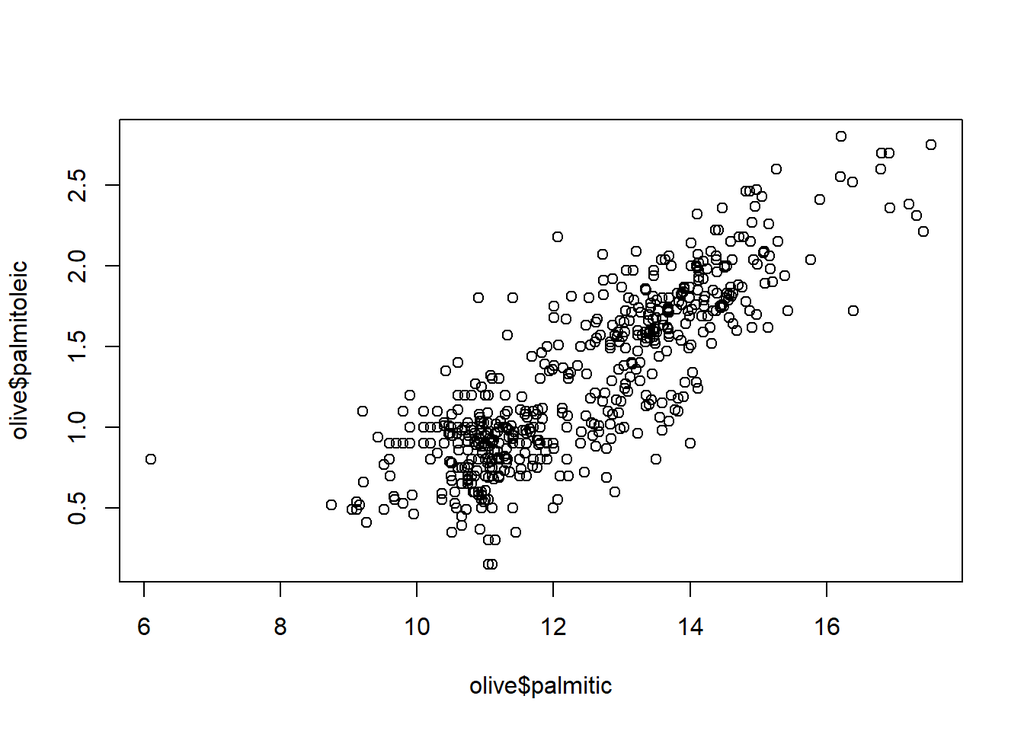

```r
plot(olive$palmitic, olive$palmitoleic) # positive relationship.
```

Create a histogram of the percentage of eicosenoic acid in olive:

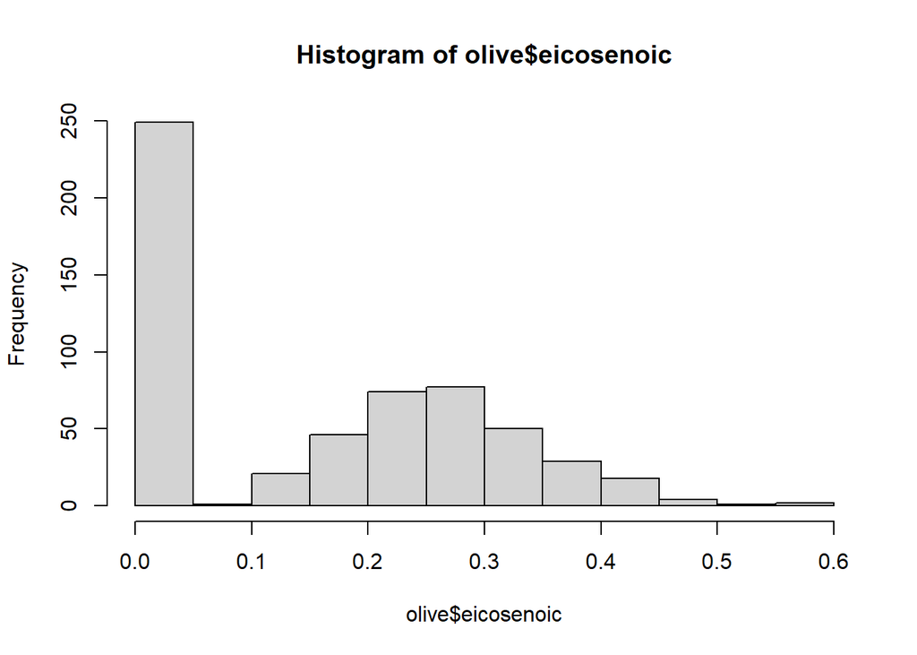

```r
hist(olive$eicosenoic) # the most common value of eicosenoic acid is below 0.05%.
```

Make a boxplot of palmitic acid percentage in olive with separate distributions for each region.

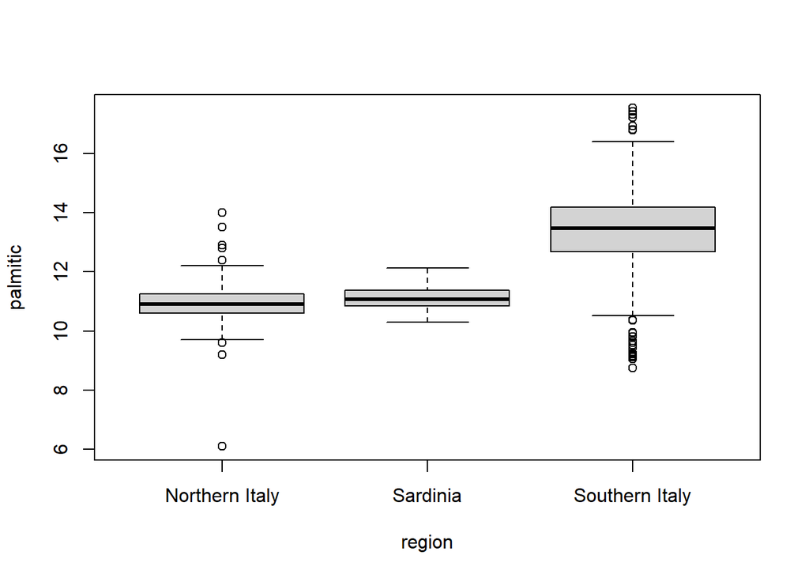

```r
boxplot(palmitic ~ region, data = olive)
```

### 5.3 The NHANES dataset

The **NHANES** dataset comes from the survey collected by the United States National Center for Health Statistics (NCHS). This center has conducted a series of health and nutrition surveys since the 1960’s. Starting in 1999, about 5,000 individuals of all ages have been interviewed every year and they complete the health examination component of the survey. Part of the data is made available via the **NHANES** package.

Install `install.packages("NHANES")` and load the **NHANES** package:

```r
library(NHANES)
data(NHANES)
```

Explore the **NHANES** data:

```r
str(NHANES)
```

```
## tibble [10,000 x 76] (S3: tbl_df/tbl/data.frame)
##  $ ID              : int [1:10000] 51624 51624 51624 51625 51630 51638 51646 51647 51647 51647 ...
##  $ SurveyYr        : Factor w/ 2 levels "2009_10","2011_12": 1 1 1 1 1 1 1 1 1 1 ...
##  $ Gender          : Factor w/ 2 levels "female","male": 2 2 2 2 1 2 2 1 1 1 ...
##  $ Age             : int [1:10000] 34 34 34 4 49 9 8 45 45 45 ...
##  $ AgeDecade       : Factor w/ 8 levels " 0-9"," 10-19",..: 4 4 4 1 5 1 1 5 5 5 ...
##  $ AgeMonths       : int [1:10000] 409 409 409 49 596 115 101 541 541 541 ...
##  $ Race1           : Factor w/ 5 levels "Black","Hispanic",..: 4 4 4 5 4 4 4 4 4 4 ...
##  $ Race3           : Factor w/ 6 levels "Asian","Black",..: NA NA NA NA NA NA NA NA NA NA ...
##  $ Education       : Factor w/ 5 levels "8th Grade","9 - 11th Grade",..: 3 3 3 NA 4 NA NA 5 5 5 ...
##  $ MaritalStatus   : Factor w/ 6 levels "Divorced","LivePartner",..: 3 3 3 NA 2 NA NA 3 3 3 ...
##  $ HHIncome        : Factor w/ 12 levels " 0-4999"," 5000-9999",..: 6 6 6 5 7 11 9 11 11 11 ...
##  $ HHIncomeMid     : int [1:10000] 30000 30000 30000 22500 40000 87500 60000 87500 87500 87500 ...
##  $ Poverty         : num [1:10000] 1.36 1.36 1.36 1.07 1.91 1.84 2.33 5 5 5 ...
##  $ HomeRooms       : int [1:10000] 6 6 6 9 5 6 7 6 6 6 ...
```

[output cut: 62 more lines]

The **NHANES** data has many missing values.

```r
sum(is.na(NHANES))
```

```
## [1] 277677
```

```r
NHANES %>% filter(AgeDecade == " 20-29", na.rm = TRUE) # note that there is a space in front of 20-29.
```

```
## # A tibble: 1,356 x 76
##       ID SurveyYr Gender   Age AgeDecade AgeMonths Race1 Race3 Education
##    <int> <fct>    <fct>  <int> <fct>         <int> <fct> <fct> <fct>
##  1 51710 2009_10  female    26 " 20-29"        319 White <NA>  College ~
##  2 51723 2009_10  male      28 " 20-29"        336 Black <NA>  Some Col~
##  3 51731 2009_10  female    28 " 20-29"        346 Black <NA>  High Sch~
##  4 51734 2009_10  male      25 " 20-29"        310 White <NA>  High Sch~
##  5 51741 2009_10  female    21 " 20-29"        253 Black <NA>  Some Col~
##  6 51741 2009_10  female    21 " 20-29"        253 Black <NA>  Some Col~
##  7 51760 2009_10  female    27 " 20-29"        334 Hisp~ <NA>  9 - 11th~
##  8 51764 2009_10  female    29 " 20-29"        357 White <NA>  College ~
##  9 51764 2009_10  female    29 " 20-29"        357 White <NA>  College ~
## 10 51764 2009_10  female    29 " 20-29"        357 White <NA>  College ~
## # ... with 1,346 more rows, and 67 more variables: MaritalStatus <fct>,
## #   HHIncome <fct>, HHIncomeMid <int>, Poverty <dbl>, HomeRooms <int>,
## #   HomeOwn <fct>, Work <fct>, Weight <dbl>, Length <dbl>, HeadCirc <dbl>,
## #   Height <dbl>, BMI <dbl>, BMICatUnder20yrs <fct>, BMI_WHO <fct>,
## #   Pulse <int>, BPSysAve <int>, BPDiaAve <int>, BPSys1 <int>, BPDia1 <int>,
## #   BPSys2 <int>, BPDia2 <int>, BPSys3 <int>, BPDia3 <int>, Testosterone <dbl>,
## #   DirectChol <dbl>, TotChol <dbl>, UrineVol1 <int>, UrineFlow1 <dbl>,
## #   UrineVol2 <int>, UrineFlow2 <dbl>, Diabetes <fct>, DiabetesAge <int>,
## #   HealthGen <fct>, DaysPhysHlthBad <int>, DaysMentHlthBad <int>,
## #   LittleInterest <fct>, Depressed <fct>, nPregnancies <int>, nBabies <int>,
## #   Age1stBaby <int>, SleepHrsNight <int>, SleepTrouble <fct>,
## #   PhysActive <fct>, PhysActiveDays <int>, TVHrsDay <fct>, CompHrsDay <fct>,
## #   TVHrsDayChild <int>, CompHrsDayChild <int>, Alcohol12PlusYr <fct>,
## #   AlcoholDay <int>, AlcoholYear <int>, SmokeNow <fct>, Smoke100 <fct>,
## #   Smoke100n <fct>, SmokeAge <int>, Marijuana <fct>, AgeFirstMarij <int>,
## #   RegularMarij <fct>, AgeRegMarij <int>, HardDrugs <fct>, SexEver <fct>,
## #   SexAge <int>, SexNumPartnLife <int>, SexNumPartYear <int>, SameSex <fct>,
## #   SexOrientation <fct>, PregnantNow <fct>
```

`BPSysAve` contains information of the blood pressure. Compute the average and standard deviation of systolic blood pressure, using the `na.rm = TRUE` to ignore the NAs:

```r
NHANES %>% filter(AgeDecade == " 20-29", na.rm = TRUE) %>%
  summarize(average = mean(BPSysAve, na.rm = TRUE),
            standard_deviation = sd(BPSysAve, na.rm = TRUE))
```

```
## # A tibble: 1 x 2
##   average standard_deviation
##     <dbl>              <dbl>
## 1    113.               11.7
```

Compute the average and standard deviation for females, but for each age group separately:

```r
NHANES %>% filter(Gender == "female") %>%
  group_by(AgeDecade, na.rm = TRUE) %>%
  summarize(average = mean(BPSysAve, na.rm = TRUE),
            standard_deviation = sd(BPSysAve, na.rm = TRUE))
```

```
## # A tibble: 9 x 4
## # Groups:   AgeDecade [9]
##   AgeDecade na.rm average standard_deviation
##   <fct>     <lgl>   <dbl>              <dbl>
## 1 " 0-9"    TRUE     100.               9.07
## 2 " 10-19"  TRUE     104.               9.46
## 3 " 20-29"  TRUE     108.              10.1
## 4 " 30-39"  TRUE     111.              12.3
## 5 " 40-49"  TRUE     115.              14.5
## 6 " 50-59"  TRUE     122.              16.2
## 7 " 60-69"  TRUE     127.              17.1
## 8 " 70+"    TRUE     134.              19.8
## 9  <NA>     TRUE     142.              22.9
```

Compare systolic blood pressure across race for males between the ages of 40-49:

```r
NHANES %>% filter(Gender == "male",
                  AgeDecade == " 40-49") %>%
  group_by(Race1) %>%
  summarize(average = mean(BPSysAve, na.rm = TRUE)) %>%
  arrange(average)
```

```
## # A tibble: 5 x 2
##   Race1    average
##   <fct>      <dbl>
## 1 White       120.
## 2 Other       120.
## 3 Hispanic    122.
## 4 Mexican     122.
## 5 Black       126.
```